# HSK

Hochschulsommerkurse

Daniel Jach

daniel.jach@outlook.com

Southwest Jiaotong University

23. Oktober 2024

## HSK: Hochschulsommerkurse

#### Programmziel

- Dieses Programm dient der **Vertiefung der Kenntnisse der deutschen Sprache** (Allgemeinsprache, Fachsprache) und Landeskunde.

#### Wer kann sich bewerben?

- Bewerben können sich Studierende in grundständigen Studiengängen (z.B. Bachelor) und Masterstudiengängen aller Fachrichtungen…
- … im 2. oder 3. Studienjahr (Bachelor) bzw. 1. oder 2. Studienjahr (Master).
- … mit einem Sprachniveau von B1 oder höher (onSET-Test).

## HSK: Hochschulsommerkurse

#### Wie können Sie sich bewerben?

- Deadline: 01. Dezember 2024
- Nötige Bewerbungsunterlagen:
  - Bewerbungsformular
  - tabellarischer Lebenslauf (deutsch)
  - Motivationsschreiben (deutsch)
  - Schul- bzw. Bachelorzeugnis mit Abschlussnote (deutsch/englisch)
  - Leistungsnachweise der letzten zwei Jahre
  - Sprachzeugnis (onSET-Zertifikat)
  - Andere relevante Nachweise
- Bewerbungsunterlagen im DAAD-Bewerbungsportal hochladen

## HSK: Hochschulsommerkurse

#### Welche Kurse werden gefördert?

- Gefördert wird die Teilnahme an sprach- und landeskundlichen sowie fachsprachlichen Kursen.
- Kursangebote: Link
  - Mindestens 18 Unterrichtstage (in der Regel 5 Tage/Woche)
  - Achten Sie Dauer, Inhalt, Kosten der Kurse
  - Wählen Sie drei mögliche Kurse aus.

#### Was umfasst das Stipendium?

- Einmalige Betrag für Unterkunft und Kurs in Höhe von 1.425 EUR
- Einmalige Stipendienzahlung (für Essen, etc.) in Höhe von 1.192 EUR
- Krankenversicherung

## HSK: Hochschulsommerkurse

#### Wie wird meine Bewerbung bewertet?

- Über die Bewerbungen entscheidet eine Auswahlkommission.
- Zentrale Auswahlkriterien sind:
  - die bisherigen akademischen Leistungen,
  - eine überzeugende Motivation mit Blick auf Studium und das weitere akademische Vorhaben

#### Wichtige Links

- Programmbeschreibung auf Chinesisch: [Link](https://www.daad.org.cn/zh/find-funding/funding-programmes-in-germany/university-summer-courses-for-foreign-students-and-graduates/)
- Programmbeschreibung auf Deutsch und **DAAD-Bewerbungsportal** („Bewerbung einreichen“): Link
- Kursangebote: Link
- Stipendienberatung: scholarship.beijing@daad.de

## HSK: Hochschulsommerkurse

#### Wie stehen meine Chancen?

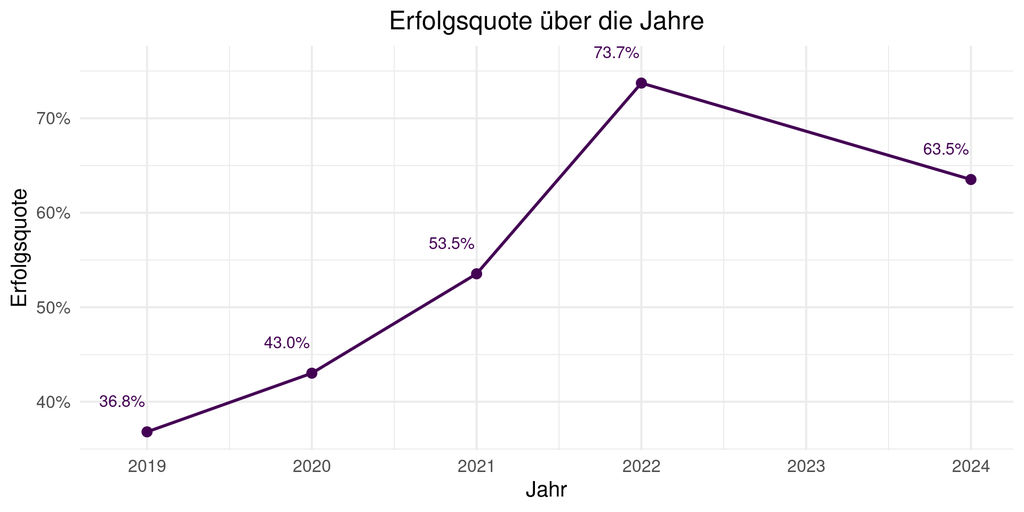

## Vielen Dank für Ihre Aufmerksamkeit